# Model 1

RW Hass

2024-02-06

In this tutorial, Model 1 (One-Way ANOVA with random effects) is illustrated along with how to extract information to compute the Intra-class Correlation ICC. We also see how to use `lme4` syntax.

### Loading the Data

Load via the data via the .csv file. Note, factors need to be set up as the data are read in as character vectors in the case of the factors.

```r
# attach lme4
library(lme4)
# set working directory manually

HSB <- read.csv("HSB_data.csv")

HSB <- within(HSB, {
  sector <- as.factor(sector)
  sex <- as.factor(sex)
  minority <- as.factor(minority)
})

# note the contrasts using
contrasts(HSB$sector)
```

```
##          Public
## Catholic      0
## Public        1
```

First we visualize the distribution of the outcome variable (Math Achievement) ignoring the school-level clustering.

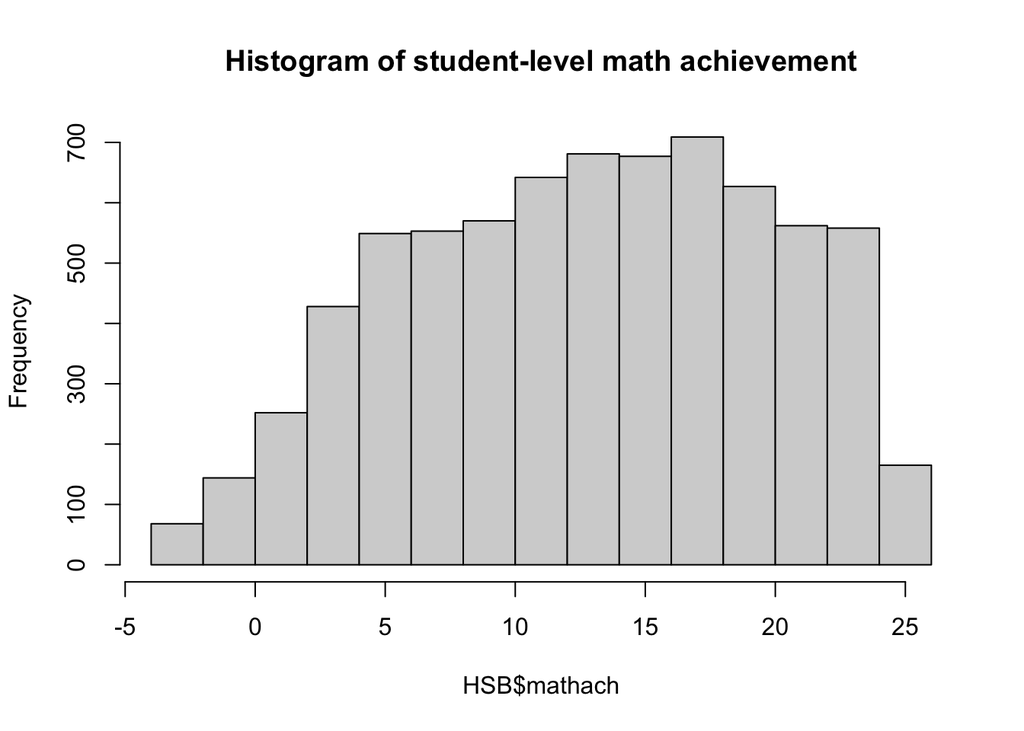

```r
# histogram
hist(HSB$mathach, main = "Histogram of student-level math achievement")
```

```r
# descriptive statistics
descHSB <- describe(HSB$mathach)
knitr::kable(descHSB[,2:5], format = "latex", digits = 2)
```

[output not shown]

As another demonstration of aggregation bias (in this case, dis-aggregation bias) we fit a trivial “model” using OLS regression to obtain an estimate of the intercept as well as a confidence interval. We pretend that we don’t know about the variance between schools, or the dependency within schools

```r
olsmod1 <- lm(mathach ~ 1, data = HSB)
summary(olsmod1)
```

```
##
## Call:
## lm(formula = mathach ~ 1, data = HSB)
##
## Residuals:
##      Min       1Q   Median       3Q      Max
## -15.5799  -5.4729   0.3831   5.5691  12.2451
##
## Coefficients:
##             Estimate Std. Error t value Pr(>|t|)
## (Intercept) 12.74785    0.08115   157.1   <2e-16 ***
## ---
## Signif. codes:  0 '***' 0.001 '**' 0.01 '*' 0.05 '.' 0.1 ' ' 1
##
## Residual standard error: 6.878 on 7184 degrees of freedom
```

```r
# this will give you the OLS estimate of sigma-squared
anova(olsmod1)
```

```
## Analysis of Variance Table
##
## Response: mathach
##             Df Sum Sq Mean Sq F value Pr(>F)
## Residuals 7184 339877   47.31
```

In contrast, here’s an OLS model for level 2, ignoring individual differences among students in each school.

Again, we’re interested in the intercept and the confidence interval. Note whether it is wider or narrower than the disaggregated model above.

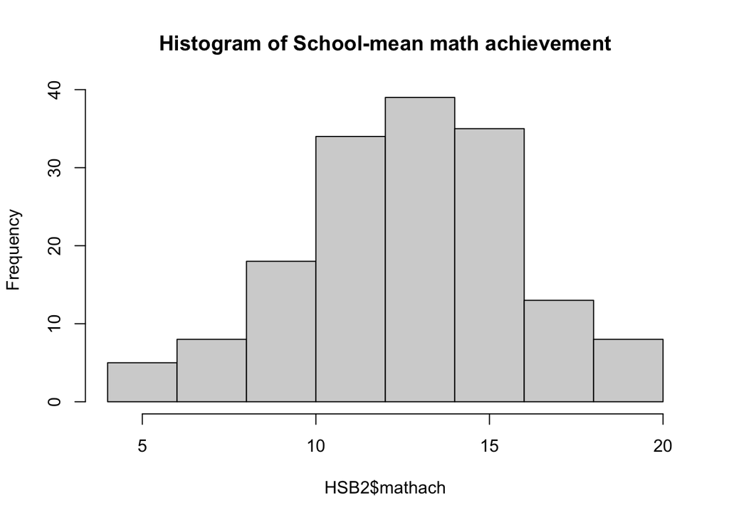

```r
HSB2 <- aggregate(mathach ~ school, data = HSB, mean)

hist(HSB2$mathach, main = "Histogram of School-mean math achievement")
```

```r
mean(HSB2$mathach)
```

```
## [1] 12.62075
```

```r
sd(HSB2$mathach)
```

```
## [1] 3.117651
```

```r
sd(HSB2$mathach)^2
```

```
## [1] 9.71975
```

```r
olsmod2 <- lm(mathach ~ 1, data = HSB2)
summary(olsmod2)
```

```
##
## Call:
## lm(formula = mathach ~ 1, data = HSB2)
##
## Residuals:
##     Min      1Q  Median      3Q     Max
## -8.3810 -2.1467  0.2754  2.0272  7.0984
##
## Coefficients:
##             Estimate Std. Error t value Pr(>|t|)
## (Intercept)  12.6208     0.2465   51.21   <2e-16 ***
## ---
## Signif. codes:  0 '***' 0.001 '**' 0.01 '*' 0.05 '.' 0.1 ' ' 1
##
## Residual standard error: 3.118 on 159 degrees of freedom
```

```r
anova(olsmod2)
```

```
## Analysis of Variance Table
##
## Response: mathach
##            Df Sum Sq Mean Sq F value Pr(>F)
## Residuals 159 1545.4  9.7197
```

Now we fit the One Way ANOVA with random effects. We use the syntax `(1|school)` which tells R that we want to model the school intercepts with a random effect.

```r
mod1 <- lmer(mathach ~ 1 + (1|school), data = HSB)

summary(mod1)
```

```
## Linear mixed model fit by REML ['lmerMod']
## Formula: mathach ~ 1 + (1 | school)
##    Data: HSB
##
## REML criterion at convergence: 47116.8
##
## Scaled residuals:
##     Min      1Q  Median      3Q     Max
## -3.0631 -0.7539  0.0267  0.7606  2.7426
##
## Random effects:
##  Groups   Name        Variance Std.Dev.
##  school   (Intercept)  8.614   2.935
##  Residual             39.148   6.257
## Number of obs: 7185, groups:  school, 160
##
## Fixed effects:
##             Estimate Std. Error t value
## (Intercept)  12.6370     0.2444   51.71
```

### Confidence Intervals

Note: the sigmas (which correspond to the tau’s in the model) are standard deviations *Square them to get variance components.*

Importantly, here we can “test” whether the $\tau_{00}$ is different from zero by looking at the confidence interval for `.sig01`

Zero is not contained in the interval, so one can argue that there is “significant” variance at level 2. However, Zero is the boundary of the parameter space, and won’t generally be in the confidence interval. Another approach is to fit a model using generalized least squares and compare the models using a likelihood ratio test.

Another test based on $\chi^{2}$ is defined in R&B but is not easily implemented in R

```r
confint(mod1)
```

```
## Computing profile confidence intervals ...
```

```
##                 2.5 %    97.5 %
## .sig01       2.594729  3.315880
## .sigma       6.154803  6.361786
## (Intercept) 12.156289 13.117121
```

Residuals at level 1 should be normally distributed with 0 as the mean

Normal Q-Q plot should show an approximately straight diagonal line

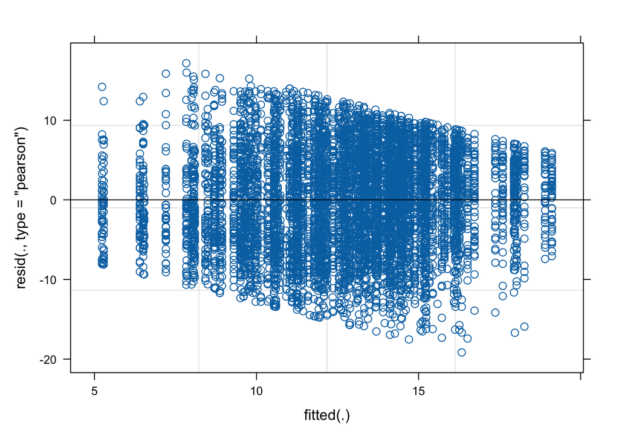

```r
plot(mod1)
```

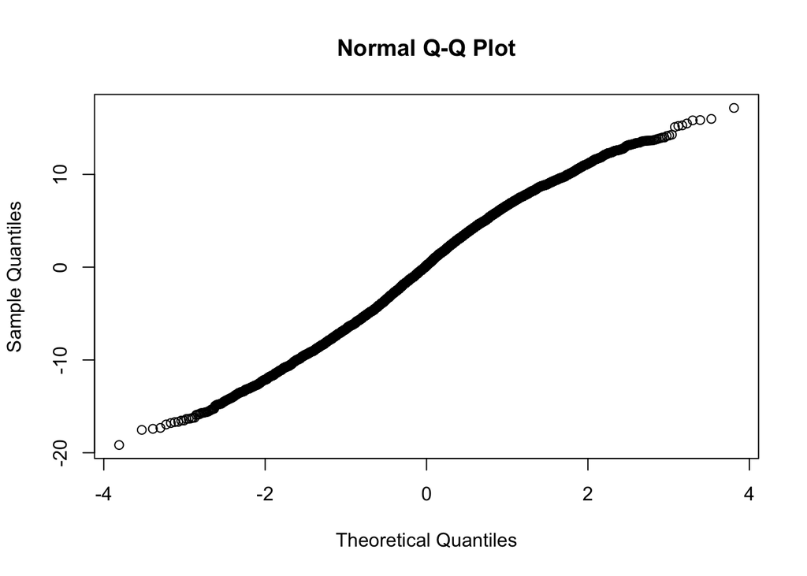

```r
qqnorm(residuals(mod1))
```

### ICC

The intraclass correlation is $\frac{\tau_{00}}{(\tau_{00}+\sigma^{2})}$

```r
vcov <- as.data.frame(VarCorr(mod1))

ICC <- vcov$vcov[1] / (vcov$vcov[1] + vcov$vcov[2])

ICC
```

```
## [1] 0.1803518
```

Plotting the distribution of intercepts ($\beta_{0j}$). By theory, the random effects should also be normally distributed with a mean of 0. We can plot that, or we can visualize the variance of the intercepts themselves. This requires estimating the intercepts, and is done using *empirical bayes* estimation: plopping in frequentist estimates for bayesian estimation.

Here are the results:

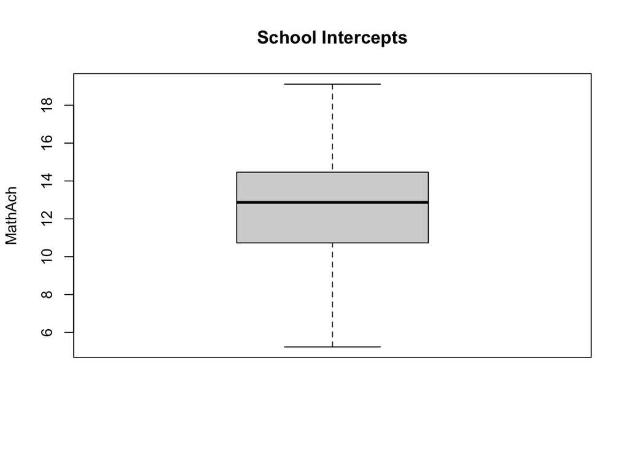

```r
# save the intercepts
beta_0 <- coef(mod1)[["school"]][1]

boxplot(beta_0$`(Intercept)`, main = "School Intercepts", ylab = "MathAch")
```

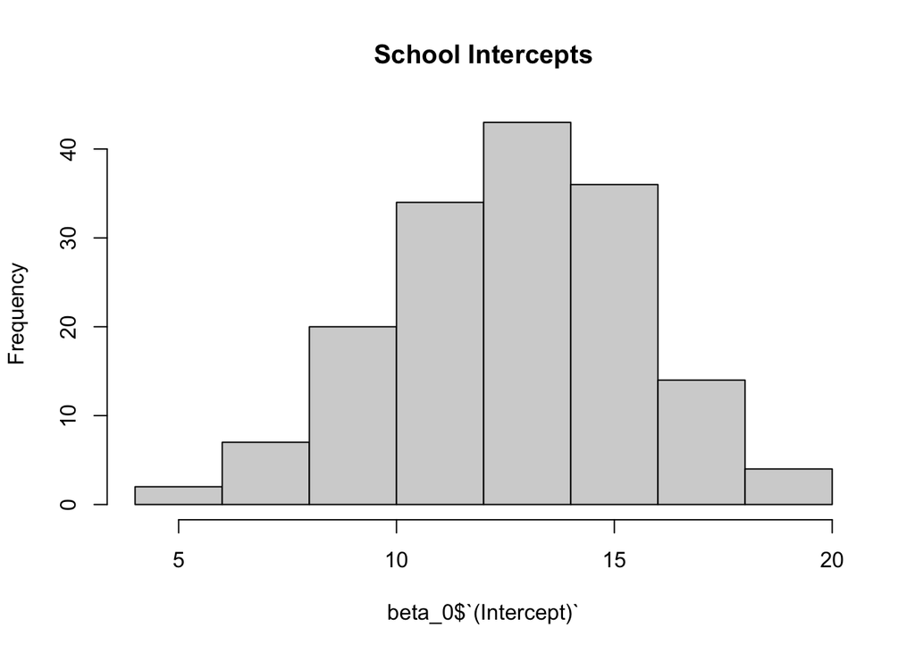

```r
hist(beta_0$`(Intercept)`, main = "School Intercepts")
```

Note, the mean of the intercepts DOES NOT equal the grand mean

```r
# mean of the intercepts
mean(beta_0$`(Intercept)`)
```

```
## [1] 12.63697
```

```r
# grand mean
mean(HSB$mathach)
```

```
## [1] 12.74785
```

Next week, we will add variables at level 2 to try to account for the variation among school-mean math achievement.